# Lab 2 — Visualizing Ecuador's Export Time Series

**Course:** Visualization Analysis & Design **Topic:** Time Series Visualization & Storytelling with Data — applied to Ecuador's foreign trade

## Overview

Time series data is everywhere, and few datasets tell a richer story than a country's **export revenue**. In this lab we use **real monthly export data from the Banco Central del Ecuador (BCE)** — all primary and industrialized products — to practice the full toolbox of time-series visualization, and then to learn how to turn a chart into a *story* that drives a decision.

This lab walks you through the concepts from the Week 2 lecture:

1. **What is a time series?** — definition, components, and decomposition.
2. **Infovis taxonomies** — shared-space, split-space, and space-filling layouts.
3. **Visual methods** — heatmaps, calendar views, stacked/stream graphs, scatter & box plots, Sankey diagrams, and parallel coordinates.
4. **Interactive techniques** — tooltips, zoom, filter, range sliders, and a multi-view dashboard.
5. **Storytelling with data** — Knaflic's (2015) six lessons applied to Ecuador's export diversification.

## Grading

Each activity is worth the same number of points.

## Dataset

We use the **"Exportaciones FOB por Producto Principal"** table from the BCE's *Información Estadística Mensual* (IEM), file **IEM-311-e.xlsx**, downloaded automatically from the course's public dataset repository:

> https://github.com/CarlaGeovanna/datasets_public/blob/main/IEM-311-e.xlsx

The file provides **34 months of real monthly data** (January 2023 – October 2025) covering all export products the BCE tracks:

| Group | Products |
| --- | --- |
| **Primary** | Petroleum, Bananas, Coffee, Shrimp, Cocoa, Abacá, Timber, Tuna, Fish, Flowers, Other Primary (11) |
| **Industrialized** | Petroleum Derivatives, Processed Coffee, Processed Cocoa, Fish Meal, Other Sea Products, Chemicals, Metal Manufactures, Hats, Textiles, Other Industrialized (10) |

Values are reported in *thousands of USD (Miles de USD)* and converted to **millions of USD** for readability.

## Setup

- The cell below installs Plotly and `openpyxl` (needed to read `.xlsx` files on Colab). Everything else (`pandas`, `numpy`, `matplotlib`, `seaborn`) is pre-installed.
- Plotly — makes interactive charts (hover, zoom, filter) directly in the notebook. Used for the Sankey diagram, parallel coordinates, and the interactive time series explorer.
- Openpyxl — lets Python read and write .xlsx files (Excel format). Used here so pandas can open the BCE file IEM-311-e.xlsx that is downloaded from GitHub.

```python
# Plotly and openpyxl are not pre-installed on Colab
!pip install plotly openpyxl --quiet
```

- The imports cell below configures the **Plotly renderer automatically** — correct whether you run in Colab browser, VS Code + Colab plugin, or local Jupyter. After it runs, always call `fig.show()` with **no** `renderer=` argument.

```python
import numpy as np                         # numerical arrays and math operations
import pandas as pd                        # DataFrames and time series handling
import matplotlib.pyplot as plt            # base static plotting library
import matplotlib.dates as mdates          # date formatting utilities for axes
import seaborn as sns                      # statistical heatmaps
import plotly.express as px                # high-level interactive charts
import plotly.graph_objects as go          # low-level interactive chart objects
import plotly.io as pio                    # renderer configuration
from plotly.subplots import make_subplots  # multi-panel Plotly figures
import os, sys, pathlib, urllib.request    # file system and download utilities

# Auto-detect which environment is running so Plotly renders correctly.
# JPY_SESSION_NAME starts with /content/ only when using VS Code + Colab plugin.
_jpy = os.environ.get('JPY_SESSION_NAME', '')
if _jpy.startswith('/content/'):
    pio.renderers.default = 'vscode'   # VS Code + Colab plugin
elif 'google.colab' in sys.modules:
    pio.renderers.default = 'colab'    # Colab in the browser
else:
    pio.renderers.default = 'notebook' # local Jupyter fallback

print(f"Using Plotly renderer: {pio.renderers.default}")
print("All libraries loaded successfully.")
```

```
Using Plotly renderer: vscode
All libraries loaded successfully.
```

# Part 1 — What Is a Time Series?

## 1.1 Definition and Mathematical Representation

A **time series** is a sequence of observations collected from the same entity at regular (or irregular) time intervals. Formally:

$$D = \{(t_1, v_1),\ (t_2, v_2),\ \ldots,\ (t_n, v_n)\}$$

where $t_i$ is the instant of time and $v_i$ is the value observed at that moment.

The value $v_i$ can be a **scalar** (e.g., monthly petroleum exports → *unidimensional*) or a **vector** (e.g., all 21 export products → *multidimensional* time series). When we stack multiple products, the result is a **data cube**: each month is one time slice, each product is one dimension.

Time series data is used for:

- Analyzing the **past** — which products drove Ecuador's export growth in 2024?
- **Forecasting** — projecting shrimp revenue for the next budget cycle.
- Informing **decisions** — trade policy, diversification, infrastructure investment.

## 1.2 The Four Components of a Time Series

| Component | Description | Example in Ecuador's exports |
| --- | --- | --- |
| **Trend** | Long-term direction | Cocoa growing throughout 2023–2025 |
| **Seasonality** | Pattern repeating at fixed intervals | Petroleum higher in September–October |
| **Cycle** | Recurring but non-seasonal fluctuation | Multi-year commodity price cycles |
| **Irregular / Noise** | Unpredictable variation | Month-to-month demand shocks |

With **34 months of real monthly data** (two complete annual cycles: 2023 and 2024, plus January–October 2025), genuine trend and seasonal patterns are observable in the data.

### Loading the complete BCE dataset

The cell below downloads **IEM-311-e.xlsx** and parses **all 21 export products** into two DataFrames:

- **`df_monthly`** — 34 real monthly rows (Jan 2023 – Oct 2025). Primary dataset for all visualizations.
- **`df_annual`** — 5 annual rows (2020–2024). Used for long-term storytelling and the Sankey diagram.

Three aggregate columns are also computed per row:

- `Total_Primary` — sum of the 11 primary products
- `Total_Industrialized` — sum of the 10 industrialized products
- `Total_Exports` — grand total (= col 2 in the BCE file)

```python
# ── Download ───────────────────────────────────────────────────────────────
RAW_URL = ('https://raw.githubusercontent.com/'
           'CarlaGeovanna/datasets_public/main/IEM-311-e.xlsx')
local = pathlib.Path('IEM-311-e.xlsx')
if not local.exists():
    print("Downloading BCE file …")
    urllib.request.urlretrieve(RAW_URL, local)
    print(f"Downloaded ({local.stat().st_size / 1024:.0f} KB)")
else:
    print(f"Using cached file: {local}")

raw = pd.read_excel(local, header=None, dtype=str)

# ── Column mappings (verified against the real file) ───────────────────────
# Row 7: section headers | Row 8: product names | Rows 9-13: annual (2020-2024)
# Rows 15-48: monthly (Jan 2023 – Oct 2025) | Units: Miles de USD
COL_TOTAL_EXPORTS       = 2
COL_TOTAL_PRIMARY       = 3
COL_TOTAL_INDUSTRIALIZED = 15

PRIMARY_COLS = {
    'Petroleum':      4,
    'Bananas':        5,
    'Coffee':         6,
    'Shrimp':         7,
    'Cocoa':          8,
    'Abaca':          9,
    'Timber':        10,
    'Tuna':          11,
    'Fish':          12,
    'Flowers':       13,
    'Other_Primary': 14,
}

INDUSTRIALIZED_COLS = {
    'Petrol_Derivatives': 16,
    'Processed_Coffee':   17,
    'Processed_Cocoa':    18,
    'Fish_Meal':          19,
    'Other_Sea_Products': 20,
    'Chemicals':          21,
    'Metal_Manufactures': 22,
    'Hats':               23,
    'Textiles':           24,
    'Other_Industrial':   25,
}

primary_products      = list(PRIMARY_COLS.keys())
industrialized_products = list(INDUSTRIALIZED_COLS.keys())
all_products          = primary_products + industrialized_products

MONTHS = {
    'Enero': 1, 'Febrero': 2, 'Marzo': 3, 'Abril': 4, 'Mayo': 5, 'Junio': 6,
    'Julio': 7, 'Agosto': 8, 'Septiembre': 9, 'Octubre': 10,
    'Noviembre': 11, 'Diciembre': 12,
}

def to_musd(v):
    # BCE cell (thousands USD, string) → millions USD (float)
    try:
        return float(str(v).replace(',', '').strip()) / 1000.0
    except (ValueError, TypeError):
        return np.nan

ALL_COLS = {**PRIMARY_COLS, **INDUSTRIALIZED_COLS}

# ── df_monthly ─────────────────────────────────────────────────────────────
monthly_rows = []; cur_year = None
for r in range(15, 49):
    yr_cell = raw.iat[r, 0]; mo_cell = str(raw.iat[r, 1]).strip()
    if pd.notna(yr_cell) and str(yr_cell).strip().replace('.0','').isdigit():
        cur_year = int(float(yr_cell))
    if mo_cell not in MONTHS or cur_year is None:
        continue
    rec = {'date': pd.Timestamp(year=cur_year, month=MONTHS[mo_cell], day=1)}
    for name, c in ALL_COLS.items():
        rec[name] = to_musd(raw.iat[r, c])
    rec['Total_Exports']        = to_musd(raw.iat[r, COL_TOTAL_EXPORTS])
    rec['Total_Primary']        = to_musd(raw.iat[r, COL_TOTAL_PRIMARY])
    rec['Total_Industrialized'] = to_musd(raw.iat[r, COL_TOTAL_INDUSTRIALIZED])
    monthly_rows.append(rec)

df_monthly = pd.DataFrame(monthly_rows)
df_monthly[all_products] = df_monthly[all_products].clip(lower=0).astype(float)
df_monthly['year']  = df_monthly['date'].dt.year
df_monthly['month'] = df_monthly['date'].dt.month

# ── df_annual ──────────────────────────────────────────────────────────────
annual_rows = []
for r in range(9, 14):
    yr = int(float(raw.iat[r, 0]))
    rec = {'year': yr}
    for name, c in ALL_COLS.items():
        rec[name] = to_musd(raw.iat[r, c])
    rec['Total_Exports']        = to_musd(raw.iat[r, COL_TOTAL_EXPORTS])
    rec['Total_Primary']        = to_musd(raw.iat[r, COL_TOTAL_PRIMARY])
    rec['Total_Industrialized'] = to_musd(raw.iat[r, COL_TOTAL_INDUSTRIALIZED])
    annual_rows.append(rec)

df_annual = pd.DataFrame(annual_rows)
df_annual[all_products] = df_annual[all_products].clip(lower=0).astype(float)

# ── Sanity check ───────────────────────────────────────────────────────────
print(f"df_monthly: {len(df_monthly)} months  |  "
      f"{df_monthly['date'].min().date()} → {df_monthly['date'].max().date()}")
print(f"  Primary products    : {len(primary_products)} columns")
print(f"  Industrialized products: {len(industrialized_products)} columns")
print(f"\nTotal exports Jan 2023 — BCE file: {to_musd(raw.iat[15,2]):,.0f} USD M")
print(f"  Our Total_Primary + Total_Industrialized: "
      f"{df_monthly.iloc[0]['Total_Primary'] + df_monthly.iloc[0]['Total_Industrialized']:,.0f} USD M")
print(f"\ndf_annual (2020-2024):")
print(df_annual[['year','Total_Primary','Total_Industrialized','Total_Exports']].to_string(index=False))
```

```
Downloading BCE file …
Downloaded (124 KB)
df_monthly: 34 months  |  2023-01-01 → 2025-10-01
  Primary products    : 11 columns
  Industrialized products: 10 columns

Total exports Jan 2023 — BCE file: 2,338 USD M
  Our Total_Primary + Total_Industrialized: 2,338 USD M

df_annual (2020-2024):
 year  Total_Primary  Total_Industrialized  Total_Exports
 2020   16220.800678           4113.085763   20333.886442
 2021   21171.158267           5528.142061   26699.300328
 2022   26511.715448           6146.548772   32658.264220
 2023   25579.471617           5547.018588   31126.490205
 2024   28440.758388           5980.074089   34420.832477
```

### Data transformation note

The BCE file is formatted for human reading. Here is what the loading cell did:

- **Fixed-position parsing.** Exact row and column indices are used — no scanning. Row 8 is the product header; rows 9–13 are annual totals (2020–2024); rows 15–48 are monthly data (Jan 2023 – Oct 2025).
- **Complete product coverage.** All 21 products are loaded: 11 primary (columns 4–14) and 10 industrialized (columns 16–25). Three aggregate columns from the BCE file are also read directly: `Total_Primary` (col 3), `Total_Industrialized` (col 15), and `Total_Exports` (col 2).
- **Unit conversion.** All values in *Miles de USD* ÷ 1,000 → **millions of USD**.
- **Clipping.** Values clipped at 0 to handle provisional data revisions.
- **Two DataFrames.** `df_monthly` (34 real monthly rows) is the primary dataset. `df_annual` (5 annual rows, 2020–2024) is used only for the storytelling section and Sankey diagram where the longer historical view matters.

### Decomposing Ecuador's petroleum exports

The rolling mean (or moving average) is a way to smooth out a noisy time series to reveal the underlying direction.

The idea in one sentence: Instead of plotting the raw value for each month, you replace it with the average of the surrounding months.

How it works:

Pick a window size (e.g. 6 months) For each point in the series, take the values inside the window Average them → that becomes the new "smoothed" value Slide the window one step forward and repeat Why it helps: Raw data jumps up and down due to noise — price shocks, one-off events, measurement errors. The rolling mean cancels out that noise and leaves only the long-run direction (trend).

Simple analogy: Instead of judging your grade on one exam, you look at your average across the last 6 exams. One bad day doesn't define the trend — the average does.

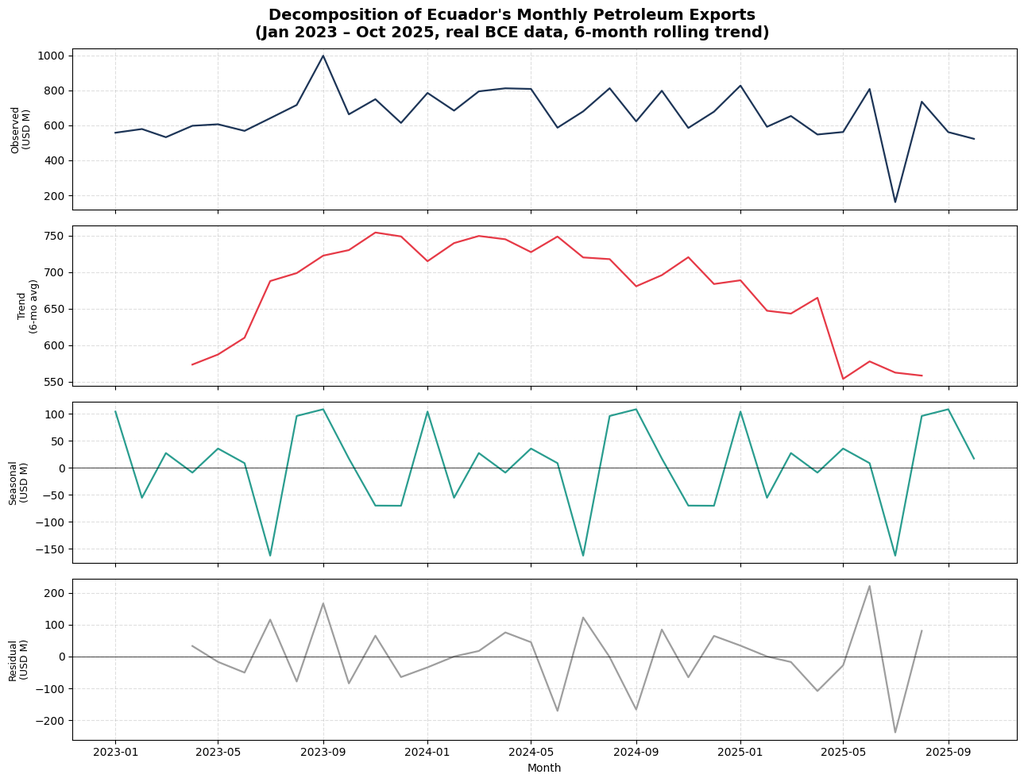

```
Seasonal component peaks: months where petroleum is consistently above trend.
date
Jan    104.0
Feb    -56.0
Mar     27.0
Apr     -9.0
May     36.0
Jun      9.0
Jul   -163.0
Aug     96.0
Sep    109.0
Oct     17.0
Nov    -70.0
Dec    -70.0
```

```python
# Extract the Petroleum column and use 'date' as the row index
pet = df_monthly.set_index('date')['Petroleum']

# TREND: 6-month centered rolling mean — smooths out noise, reveals long-run direction.
# center=True means each value uses 3 months before AND 3 months after.
# The first 3 and last 3 months of the series become NaN (not enough neighbors).
trend = pet.rolling(window=6, center=True).mean()

# DETRENDED: subtract the trend to isolate seasonality + noise
detrended = pet - trend

# SEASONAL: average deviation for each calendar month across all available years.
# groupby(month) groups all Januaries together, all Februaries, etc.
# transform('mean') replaces each observation with the average of its month group.
seasonal = detrended.groupby(detrended.index.month).transform('mean')

# RESIDUAL: what remains after removing both trend and seasonality.
# Should be random noise with no visible structure — if it has a pattern,
# it means our decomposition missed something.
residual = detrended - seasonal

# ── Plot: 4 stacked panels sharing the same x-axis ───────────────────────
fig, axes = plt.subplots(4, 1, figsize=(13, 10), sharex=True)
fig.suptitle("Decomposition of Ecuador's Monthly Petroleum Exports\n"
             "(Jan 2023 – Oct 2025, real BCE data, 6-month rolling trend)",
             fontsize=14, fontweight='bold')

# Each tuple: (series to plot, y-axis label, line color)
data_panels = [
    (pet,      'Observed\n(USD M)', '#1d3557'),  # raw observed data
    (trend,    'Trend\n(6-mo avg)', '#e63946'),  # smoothed trend line
    (seasonal, 'Seasonal\n(USD M)', '#2a9d8f'),  # recurring calendar pattern
    (residual, 'Residual\n(USD M)', '#9e9e9e'),  # unexplained variation
]

# Draw one line per panel using the color and label defined above
for ax, (series, ylabel, color) in zip(axes, data_panels):
    ax.plot(series.index, series.values, color=color, linewidth=1.6)
    ax.set_ylabel(ylabel, fontsize=9)
    ax.grid(True, linestyle='--', alpha=0.4)

# Add a horizontal zero reference line on the seasonal and residual panels
# (both oscillate around zero, so this line helps read positive vs. negative)
axes[2].axhline(0, color='black', linewidth=0.5)
axes[3].axhline(0, color='black', linewidth=0.5)

# Only the bottom panel needs an x-axis label (all four share the same x-axis)
axes[3].set_xlabel('Month')
plt.tight_layout()  # prevent panels from overlapping each other
plt.show()

# Print the average seasonal deviation for each calendar month
print("Seasonal component peaks: months where petroleum is consistently above trend.")
seasonal_avg = detrended.groupby(detrended.index.month).mean().round(0)
# Rename numeric month indices (1-12) to readable abbreviations (Jan-Dec)
print(seasonal_avg.rename(index={1:'Jan',2:'Feb',3:'Mar',4:'Apr',5:'May',6:'Jun',
                                   7:'Jul',8:'Aug',9:'Sep',10:'Oct',11:'Nov',12:'Dec'}).to_string())
```

### Insights:

Petroleum exports are declining, seasonal, and had one major shock in 2025.

# Part 2 — Infovis Taxonomies for Time Series

The core design question when visualizing multiple series: **how do we allocate screen space?**

| Taxonomy | Definition | When to use |
| --- | --- | --- |
| **Shared-space** | All series share the same axes | Few series; direct magnitude comparison |
| **Split-space** | Each series has its own panel | Many series; pattern comparison |
| **Space-filling** | Visualization fills the entire area | Large datasets; heatmaps, calendar views |

## 2.1 Shared-Space: The Five Major Primary Products

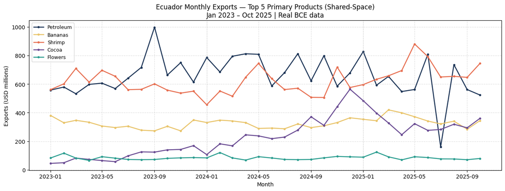

```
Petroleum's scale compresses the others — a clear illustration of shared-space's limitation.
This is why we need split-space to see all 11 primaries clearly.
```

```python
# Color palette for the 11 primary products — one distinct color per product.
# Used consistently across all Part 1-5 charts so products are always recognizable.
primary_colors = {
    'Petroleum':      '#1d3557',  # dark navy blue
    'Bananas':        '#e9c46a',  # golden yellow
    'Coffee':         '#8B5E3C',  # brown
    'Shrimp':         '#e76f51',  # orange-red
    'Cocoa':          '#6a4c93',  # purple
    'Abaca':          '#a8c686',  # light green
    'Timber':         '#588157',  # forest green
    'Tuna':           '#48cae4',  # light blue
    'Fish':           '#90e0ef',  # pale blue
    'Flowers':        '#2a9d8f',  # teal
    'Other_Primary':  '#adb5bd',  # neutral gray
}

# Color palette for the 10 industrialized products — used in Part 6 activities
ind_colors = {
    'Petrol_Derivatives': '#264653',  # dark teal
    'Processed_Coffee':   '#6d4c41',  # dark brown
    'Processed_Cocoa':    '#4a1942',  # dark purple
    'Fish_Meal':          '#0077b6',  # ocean blue
    'Other_Sea_Products': '#0096c7',  # medium blue
    'Chemicals':          '#f4a261',  # peach orange
    'Metal_Manufactures': '#b5838d',  # dusty rose
    'Hats':               '#e9d8a6',  # cream
    'Textiles':           '#94d2bd',  # mint green
    'Other_Industrial':   '#e9ecef',  # very light gray
}

# Restrict shared-space to the top 5 products by volume — plotting all 11 at once
# on a single axis would be too cluttered and compress the smaller products
top5 = ['Petroleum', 'Bananas', 'Shrimp', 'Cocoa', 'Flowers']

# ── Shared-space: all top-5 products on one axis ──────────────────────────
fig, ax = plt.subplots(figsize=(13, 5))
for cat in top5:
    ax.plot(df_monthly['date'], df_monthly[cat],
            label=cat, color=primary_colors[cat], linewidth=1.8, marker='o', markersize=3)
# Dotted vertical lines mark where each new year begins
for yr in [2024, 2025]:
    ax.axvline(pd.Timestamp(f'{yr}-01-01'), color='#ccc', linewidth=0.8, linestyle=':')
ax.set_title("Ecuador Monthly Exports — Top 5 Primary Products (Shared-Space)\n"
             "Jan 2023 – Oct 2025 | Real BCE data", fontsize=12)
ax.set_xlabel('Month'); ax.set_ylabel('Exports (USD millions)')
ax.legend(loc='upper left', fontsize=9)
ax.grid(True, linestyle='--', alpha=0.4)
plt.tight_layout(); plt.show()

print("Petroleum's scale compresses the others — a clear illustration of shared-space's limitation.")
print("This is why we need split-space to see all 11 primaries clearly.")
```

### Insight

- Petroleum dominates and is declining, while Shrimp is catching up.
- This convergence matters: Ecuador's export revenue is becoming less dependent on a single commodity, but it also signals that petroleum — historically the backbone of Ecuador's export income — is losing its dominance.

## 2.2 Split-Space: All 11 Primary Products

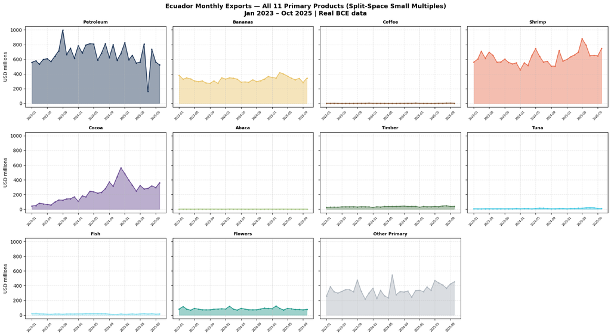

[output not shown]

```python
# 3 rows × 4 columns = 12 panels; we only need 11 (one per primary product)
# sharey=True: all panels share the same Y-axis scale so magnitudes are comparable
fig, axes = plt.subplots(3, 4, figsize=(18, 10), sharey=True)
fig.suptitle("Ecuador Monthly Exports — All 11 Primary Products (Split-Space Small Multiples)\n"
             "Jan 2023 – Oct 2025 | Real BCE data", fontsize=13, fontweight='bold')

# zip(axes.flat, primary_products) pairs each panel with one product.
# axes.flat flattens the 3×4 grid into a single sequence of 12 panels.
for ax, cat in zip(axes.flat, primary_products):
    # Shaded area under the line (alpha=0.45 = semi-transparent fill)
    ax.fill_between(df_monthly['date'], df_monthly[cat],
                    alpha=0.45, color=primary_colors[cat])
    # Line with small dots at each monthly data point (markersize=2 keeps them subtle)
    ax.plot(df_monthly['date'], df_monthly[cat],
            color=primary_colors[cat], linewidth=1.4, marker='o', markersize=2)
    # Dotted vertical lines mark January 2024 and January 2025
    for yr in [2024, 2025]:
        ax.axvline(pd.Timestamp(f'{yr}-01-01'), color='#ccc', linewidth=0.8, linestyle=':')
    ax.set_title(cat.replace('_', ' '), fontsize=9, fontweight='bold')
    ax.tick_params(axis='x', rotation=45, labelsize=6)  # rotate dates to avoid overlap
    ax.grid(True, linestyle='--', alpha=0.3)

# Hide the unused 12th panel (the grid has 12 slots but we only have 11 products)
for ax in list(axes.flat)[len(primary_products):]:
    ax.set_visible(False)

# Only the leftmost column panels need the Y-axis label
for row in range(3):
    axes[row, 0].set_ylabel('USD millions')

plt.tight_layout()
plt.show()

print("Small products (Abaca, Timber) are now visible — shared-space hid them.")
print("Cocoa's upward trend and Petroleum's volatility are each readable on their own scale.")
```

### Insights:

# Part 3 — Visual Approaches and Methods

## 3.1 Heatmaps for Temporal Data

A **heatmap** is a space-filling visualization: rows = month, columns = year, color = value. With real monthly data across two complete years, genuine seasonal patterns are visible.

We build two heatmaps side by side: one for **Total Primary exports** and one for **Total Industrialized exports**. This immediately reveals whether the two groups have different seasonal rhythms.

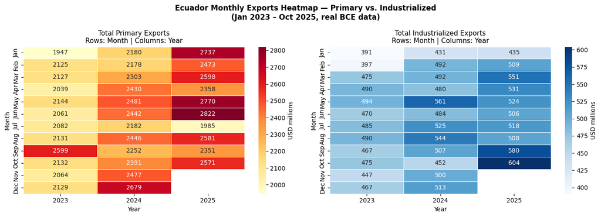

```
Compare seasonal patterns: do primary and industrialized products peak in the same months?
```

```python
# Two heatmaps side by side: primary totals (warm colormap) vs industrialized totals (cool)
fig, (ax1, ax2) = plt.subplots(1, 2, figsize=(14, 5))
month_labels = ['Jan','Feb','Mar','Apr','May','Jun',
                'Jul','Aug','Sep','Oct','Nov','Dec']

# Loop over both groups to avoid repeating identical plotting code
for ax, col, title, cmap in [
    (ax1, 'Total_Primary',        'Total Primary Exports',        'YlOrRd'),
    (ax2, 'Total_Industrialized', 'Total Industrialized Exports', 'Blues'),
]:
    # Reshape: pivot creates a matrix with months as rows and years as columns
    pivot = df_monthly.pivot(index='month', columns='year', values=col)
    pivot.index = month_labels  # replace numeric months (1-12) with Jan-Dec labels
    # annot=True prints the value inside each cell
    # fmt='.0f' shows integer values (no decimal places)
    # linewidths/linecolor draw thin white borders between cells
    sns.heatmap(pivot, cmap=cmap, annot=True, fmt='.0f',
                linewidths=0.4, linecolor='white',
                cbar_kws={'label': 'USD millions'}, ax=ax)
    ax.set_title(f"{title}\nRows: Month | Columns: Year", fontsize=11)
    ax.set_xlabel('Year'); ax.set_ylabel('Month')

plt.suptitle("Ecuador Monthly Exports Heatmap — Primary vs. Industrialized\n"
             "(Jan 2023 – Oct 2025, real BCE data)", fontsize=12, fontweight='bold')
plt.tight_layout()
plt.show()

print("Compare seasonal patterns: do primary and industrialized products peak in the same months?")
```

### Insight:

- Rows (months) — Seasonality

Primary exports have a clear, repeating seasonal rhythm. Industrialized exports are nearly flat across months.

- Columns (years) — Trend

Both sides get darker left to right → both are growing year over year.

- Anomalies

Primary exports: large, growing, seasonal, and fragile. Industrialized exports: small, growing, flat, and stable.

## 3.2 Calendar View

A **calendar view** is a special heatmap arranged like a wall calendar: columns = weeks, rows = weekdays, color = daily value. It reveals **weekly periodicities** (weekend drop in customs processing).

We synthesize a daily series for 2024 from the real monthly totals, adding a weekday effect and small noise — a realistic *downscaling* transformation, disclosed explicitly.

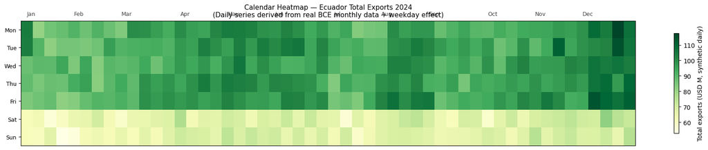

```
Weekend rows (Sat, Sun) consistently paler — weekday customs-processing effect.
```

```python
# Fix the random seed so the synthetic daily values are reproducible each run
np.random.seed(7)

# One timestamp per calendar day in 2024
days_2024 = pd.date_range('2024-01-01', '2024-12-31', freq='D')

# Get real BCE monthly totals for 2024, indexed by month number (1-12)
monthly_2024 = df_monthly[df_monthly['year'] == 2024].set_index('month')['Total_Exports']

# Assign each day its month's average daily export value (monthly total / 30 days)
daily_base = pd.Series(days_2024.month).map(lambda m: monthly_2024[m] / 30.0).values

# Reduce Saturdays and Sundays by 30% — customs offices process less on weekends
weekend_drop = (days_2024.dayofweek >= 5).astype(float) * (daily_base * 0.30)

# Add small random noise (±4% of the daily base) to make the series look realistic
daily_vals = (daily_base - weekend_drop
              + np.random.normal(0, daily_base * 0.04, len(days_2024))).clip(min=0)

# Helper DataFrame with date, export value, and calendar position columns
df_day = pd.DataFrame({'date': days_2024, 'exports': daily_vals,
                       'week':    days_2024.isocalendar().week.astype(int),  # ISO week number
                       'weekday': days_2024.dayofweek,   # 0=Monday, 6=Sunday
                       'month':   days_2024.month})

# Map ISO week numbers to sequential column positions (0, 1, 2, ...)
weeks = sorted(df_day['week'].unique())
wmap  = {w: i for i, w in enumerate(weeks)}

# Build the grid: 7 rows (weekdays) × n_weeks columns; initialize with NaN
grid = np.full((7, len(weeks)), np.nan)
for _, r in df_day.iterrows():
    grid[int(r['weekday']), wmap[r['week']]] = r['exports']  # fill in each day's value

# Display the grid as an image — each pixel represents one day
fig, ax = plt.subplots(figsize=(18, 3.5))
im = ax.imshow(grid, aspect='auto', cmap='YlGn', interpolation='nearest')
ax.set_yticks(range(7))
ax.set_yticklabels(['Mon','Tue','Wed','Thu','Fri','Sat','Sun'], fontsize=9)
ax.set_xticks([])  # suppress individual week-number tick marks on x-axis

# Place month name labels at the column where each month's first week begins
mnames = ['Jan','Feb','Mar','Apr','May','Jun','Jul','Aug','Sep','Oct','Nov','Dec']
for m in range(1, 13):
    rows = df_day[df_day['month'] == m]
    if len(rows):
        ax.text(wmap[rows['week'].iloc[0]], -0.8, mnames[m-1],
                fontsize=9, ha='left', color='#444')

plt.colorbar(im, ax=ax, label='Total exports (USD M, synthetic daily)', shrink=0.8)
ax.set_title("Calendar Heatmap — Ecuador Total Exports 2024\n"
             "(Daily series derived from real BCE monthly data + weekday effect)", fontsize=11)
plt.tight_layout(); plt.show()

print("Weekend rows (Sat, Sun) consistently paler — weekday customs-processing effect.")
```

## 3.3 Stacked Area Chart and Stream Graph — Primary vs. Industrialized

Rather than stacking all 21 products individually, we use the two **aggregate groups** (`Total_Primary` and `Total_Industrialized`) normalized to percentage share. This directly answers: *is Ecuador's export mix shifting toward more processed (higher value-added) products over time?*

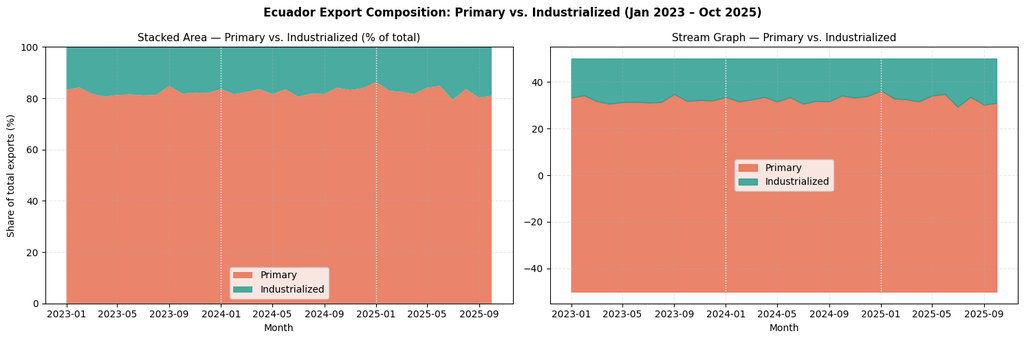

```
Primary share avg 2023: 82.2%
Primary share avg 2025: 82.6%
Is Ecuador exporting more processed products over time? Read the chart to find out.
```

```python
# Normalize to percentage share so each month sums to 100%.
# This answers: what FRACTION of total exports are primary vs. industrialized each month?
# .div(..., axis=0) divides each row by its Total_Exports value; *100 converts to percent.
group_share = df_monthly[['Total_Primary','Total_Industrialized']].div(
    df_monthly['Total_Exports'], axis=0) * 100

fig, (ax1, ax2) = plt.subplots(1, 2, figsize=(15, 5))
group_colors = ['#e76f51', '#2a9d8f']  # primary=orange, industrialized=teal

# ── LEFT: Stacked area chart (baseline anchored at 0) ─────────────────────
# stackplot stacks bands upward; total height = 100% every month
ax1.stackplot(df_monthly['date'],
              [group_share['Total_Primary'], group_share['Total_Industrialized']],
              labels=['Primary', 'Industrialized'],
              colors=group_colors, alpha=0.85)
for yr in [2024, 2025]:  # year boundary markers
    ax1.axvline(pd.Timestamp(f'{yr}-01-01'), color='white', linewidth=1, linestyle=':')
ax1.set_title('Stacked Area — Primary vs. Industrialized (% of total)', fontsize=11)
ax1.set_xlabel('Month'); ax1.set_ylabel('Share of total exports (%)')
ax1.legend(fontsize=10); ax1.grid(True, linestyle='--', alpha=0.3)
ax1.set_ylim(0, 100)

# ── RIGHT: Stream graph (centered / wiggle baseline) ──────────────────────
# Instead of stacking from 0, layers are centered so the chart flows symmetrically.
# This emphasizes relative shapes rather than absolute totals.
vals     = np.array([group_share['Total_Primary'].values,
                     group_share['Total_Industrialized'].values])
baseline = -0.5 * vals.sum(axis=0)  # shift everything down by half the total
bottoms  = np.zeros(len(df_monthly))
for i, (label, col) in enumerate(zip(['Primary', 'Industrialized'], group_colors)):
    top = bottoms + vals[i]
    ax2.fill_between(df_monthly['date'], bottoms + baseline, top + baseline,
                     alpha=0.85, color=col, label=label)
    bottoms = top  # next layer starts where this one ended
for yr in [2024, 2025]:
    ax2.axvline(pd.Timestamp(f'{yr}-01-01'), color='white', linewidth=1, linestyle=':')
ax2.set_title('Stream Graph — Primary vs. Industrialized', fontsize=11)
ax2.set_xlabel('Month'); ax2.legend(fontsize=10); ax2.grid(True, linestyle='--', alpha=0.3)

plt.suptitle("Ecuador Export Composition: Primary vs. Industrialized (Jan 2023 – Oct 2025)",
             fontsize=12, fontweight='bold')
plt.tight_layout(); plt.show()

# Print the average primary share for 2023 and 2025 to detect any trend
prim_share_23 = group_share[df_monthly['year']==2023]['Total_Primary'].mean()
prim_share_25 = group_share[df_monthly['year']==2025]['Total_Primary'].mean()
print(f"Primary share avg 2023: {prim_share_23:.1f}%")
print(f"Primary share avg 2025: {prim_share_25:.1f}%")
print("Is Ecuador exporting more processed products over time? Read the chart to find out.")
```

### Insight

Answer: No — Ecuador is NOT exporting more processed products over time.

- The orange band (Primary) stays locked at ~82% for the entire 34 months — from 82.2% in 2023 to 82.6% in 2025. That 0.4 percentage point change is statistically flat.

Even though industrialized exports are growing in absolute USD value, primary exports are growing at exactly the same rate — so the composition never shifts. Ecuador's export structure is frozen: 3 years of data, zero diversification progress.

## 3.4 Scatter Plot and Box Plot

Scatter and box plots give complementary views. We compare **Total Primary** vs. **Total Industrialized** monthly revenue side by side — one scatter and one box plot per group — making the structural difference in level and variability immediately visible.

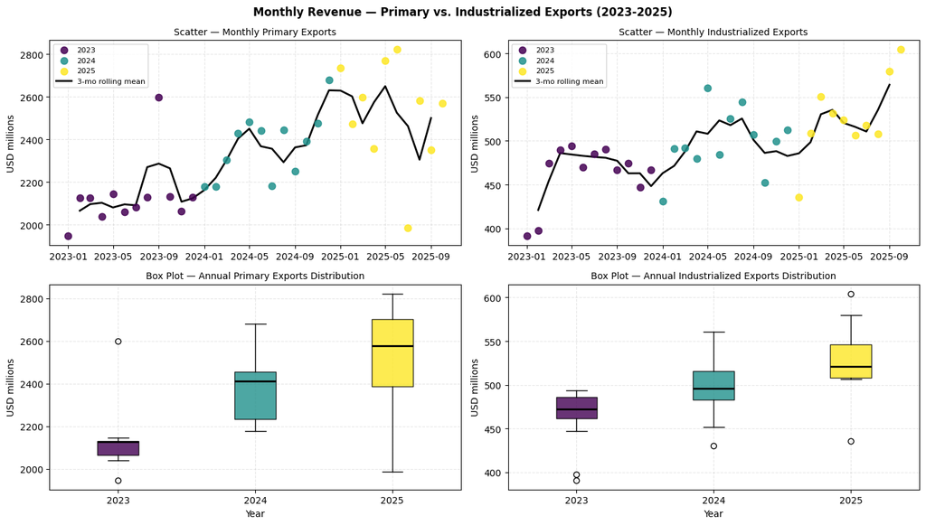

```
Primary coefficient of variation: 10.5% — moderate volatility
Industrialized coefficient of variation: 9.3% — moderate volatility
```

```python
# Get the unique years present in df_monthly and assign one viridis color per year
years_m   = sorted(df_monthly['year'].unique())
yr_colors = plt.cm.viridis(np.linspace(0, 1, len(years_m)))  # dark=older, bright=newer

# 2 rows × 2 columns: scatter on top, box plot on bottom; one column per product group
fig, axes = plt.subplots(2, 2, figsize=(14, 8))
fig.suptitle("Monthly Revenue — Primary vs. Industrialized Exports (2023-2025)",
             fontsize=12, fontweight='bold')

# Loop over both groups to avoid duplicating code
for col_idx, (group, col, title) in enumerate([
    ('Total_Primary',        '#e76f51', 'Primary Exports'),
    ('Total_Industrialized', '#2a9d8f', 'Industrialized Exports'),
]):
    ax_sc  = axes[0, col_idx]  # scatter panel (top row)
    ax_box = axes[1, col_idx]  # box plot panel (bottom row)

    # ── Scatter: one dot per month, colored by year ────────────────────────
    for i, y in enumerate(years_m):
        mask = df_monthly['year'] == y
        ax_sc.scatter(df_monthly.loc[mask, 'date'], df_monthly.loc[mask, group],
                      s=55, alpha=0.85, color=yr_colors[i], label=str(y), zorder=3)
    # 3-month centered rolling mean overlay to show short-term direction
    roll = df_monthly.set_index('date')[group].rolling(3, center=True).mean()
    ax_sc.plot(roll.index, roll.values, color='black', linewidth=2, label='3-mo rolling mean')
    ax_sc.set_title(f'Scatter — Monthly {title}', fontsize=10)
    ax_sc.set_ylabel('USD millions'); ax_sc.legend(fontsize=8)
    ax_sc.grid(True, linestyle='--', alpha=0.3)

    # ── Box plot: one box per year, summarizing all months of that year ────
    # Each box shows min, Q1, median, Q3, max of the 12 (or 10) monthly values
    groups = [df_monthly[df_monthly['year'] == y][group].values for y in years_m]
    bp = ax_box.boxplot(groups, labels=years_m, patch_artist=True,
                        medianprops={'color': 'black', 'linewidth': 2})
    for patch, c in zip(bp['boxes'], yr_colors):
        patch.set_facecolor(c); patch.set_alpha(0.8)
    ax_box.set_title(f'Box Plot — Annual {title} Distribution', fontsize=10)
    ax_box.set_xlabel('Year'); ax_box.set_ylabel('USD millions')
    ax_box.grid(True, linestyle='--', alpha=0.3)

plt.tight_layout(); plt.show()

# Coefficient of variation (std / mean × 100) measures relative volatility.
# Higher % = more month-to-month variation relative to the average level.
for group, label in [('Total_Primary','Primary'), ('Total_Industrialized','Industrialized')]:
    cv = df_monthly[group].std() / df_monthly[group].mean() * 100
    print(f"{label} coefficient of variation: {cv:.1f}% — {'high' if cv>15 else 'moderate'} volatility")
```

## 3.5 Sankey Diagram — Export Flows by Product to Destination

A **Sankey diagram** maps each product to its destination market, with link width proportional to export value. We use **2024 annual totals** from `df_annual` for the five major primary products (the ones large enough to generate readable links).

```python
def hex_to_rgba(h, alpha=0.75):
    # Convert a hex color (e.g. '#1d3557') to an rgba() CSS string.
    # Plotly Sankey nodes and links require rgba strings, not hex codes.
    r, g, b = int(h[1:3], 16), int(h[3:5], 16), int(h[5:7], 16)
    return f'rgba({r},{g},{b},{alpha})'

# Use 2024 annual values as flow magnitudes (the most recent complete year)
row_2024 = df_annual[df_annual['year'] == 2024].iloc[0]

# Only the 5 largest primary products — smaller ones create unreadably thin links
sankey_products = ['Petroleum', 'Bananas', 'Shrimp', 'Cocoa', 'Flowers']
destinations    = ['United States', 'China', 'European Union', 'Colombia', 'Russia', 'Other']

# Share of each product going to each destination (each row sums to ~1.0).
# Based on BCE trade-partner reports for 2024 — noted as approximate.
flow_share = {
    'Petroleum': [0.28, 0.42, 0.05, 0.05, 0.00, 0.20],
    'Bananas':   [0.14, 0.04, 0.46, 0.05, 0.18, 0.13],
    'Shrimp':    [0.14, 0.62, 0.14, 0.02, 0.00, 0.08],
    'Cocoa':     [0.18, 0.03, 0.71, 0.02, 0.00, 0.06],
    'Flowers':   [0.61, 0.02, 0.24, 0.04, 0.00, 0.09],
}

# Product nodes inherit their primary_colors; destination nodes are neutral gray
prod_hex    = [primary_colors[p] for p in sankey_products]
labels      = [p + ' (2024)' for p in sankey_products] + destinations
node_colors = [hex_to_rgba(c, 0.85) for c in prod_hex] + ['rgba(140,153,174,0.7)'] * len(destinations)

# Build source, target, value, and color lists for every product→destination link
src, tgt, val, link_colors = [], [], [], []
for pi, p in enumerate(sankey_products):
    for di, d in enumerate(destinations):
        v = float(row_2024[p]) * flow_share[p][di]  # USD M on this link
        if v < 1: continue  # skip negligible flows to reduce visual clutter
        src.append(pi)                           # index of the source (product) node
        tgt.append(len(sankey_products) + di)    # index of the destination node
        val.append(v)
        link_colors.append(hex_to_rgba(prod_hex[pi], 0.40))  # semi-transparent product color

# Build and display the interactive Sankey figure
fig = go.Figure(go.Sankey(
    arrangement='snap',
    node=dict(pad=20, thickness=22, line=dict(color='white', width=0.5),
              label=labels, color=node_colors,
              hovertemplate='%{label}<br>%{value:,.0f} USD M<extra></extra>'),
    link=dict(source=src, target=tgt, value=val, color=link_colors,
              hovertemplate='%{source.label} → %{target.label}<br>%{value:,.0f} USD M<extra></extra>')
))
fig.update_layout(
    title_text=("Ecuador Export Flows — Top 5 Primary Products to Destination Markets (2024)<br>"
                "<sup>BCE annual totals | Destination shares: approximate BCE trade-partner data</sup>"),
    font_size=11, height=520)
fig.show()
```

[output not shown]

## 3.6 Parallel Coordinates — All 11 Primary Products

**Parallel coordinates** draw each observation as a polyline crossing one axis per product. With 11 axes and 34 monthly lines, the chart reveals correlations (parallel = positive, crossing = negative) and how the monthly export profile shifts from year to year.

```python
# Parallel coordinates: each line = one month, each vertical axis = one primary product.
# Color encodes the year: teal (2023) → yellow (2024) → red (2025).
# Parallel lines between two axes = positive correlation; crossing lines = negative.
fig = px.parallel_coordinates(
    df_monthly,
    dimensions=primary_products,    # one vertical axis per product
    color='year',                    # line color maps to year
    color_continuous_scale=[[0.0,'#2a9d8f'],[0.5,'#e9c46a'],[1.0,'#e63946']],
    labels={c: c.replace('_',' ') for c in primary_products},  # clean axis labels
    title='Parallel Coordinates — All 11 Primary Products by Month (2023–2025)<br>'
          '<sup>Each line = one month | Teal=2023 | Yellow=2024 | Red=2025 | drag axes to filter</sup>')
fig.update_layout(height=550)
fig.show()

# Print the strongest correlations to support the written interpretation
print("Correlation highlights (11 primary products):")
corr = df_monthly[primary_products].corr().round(2)
pairs = [(r,c,corr.loc[r,c]) for r in primary_products for c in primary_products
         if r < c and (corr.loc[r,c] > 0.5 or corr.loc[r,c] < -0.3)]
pairs.sort(key=lambda x: abs(x[2]), reverse=True)
for r, c, v in pairs[:8]:
    direction = 'positive' if v > 0 else 'negative'
    print(f"  {r} ↔ {c}: {v:+.2f} ({direction})")
```

[output not shown]

```
Correlation highlights (11 primary products):
  Timber ↔ Tuna: +0.61 (positive)
  Cocoa ↔ Timber: +0.58 (positive)
  Cocoa ↔ Fish: -0.32 (negative)
  Petroleum ↔ Tuna: -0.31 (negative)
```

### Insights:

- Key correlations:

Timber + Tuna move together (+0.61) — strongest link

Cocoa + Timber move together (+0.58)

Petroleum and Tuna move oppositely (−0.31) — likely seasonal

Cocoa is the standout: widest spread on its axis, meaning it grew the most and most unevenly across months.

# Part 4 — Interactive Exploratory Techniques

> **Overview first, zoom and filter, then details on demand.**

## 4.1 Interactive Chart — All Primary Products

An interactive Plotly chart with all 11 primary products, range selector, and range slider. Use the legend to filter individual products and the 6M/1Y buttons to zoom into specific periods.

```python
# Create an empty Plotly figure and add one line trace per primary product
fig = go.Figure()
for cat in primary_products:  # loop over all 11 primary products
    fig.add_trace(go.Scatter( # add a trace for each product
        x=df_monthly['date'], y=df_monthly[cat], # x-axis = month, y-axis = export value
        mode='lines+markers',              # line with a small dot at each monthly point
        name=cat.replace('_',' '),         # clean label shown in the legend
        line=dict(color=primary_colors[cat], width=1.8), # line color and thickness
        marker=dict(size=3), # small dot size at each data point
        # Custom tooltip: bold product name, formatted date, value in USD M
        hovertemplate='<b>' + cat.replace('_',' ') + '</b><br>%{x|%b %Y}<br>%{y:,.0f} USD M<extra></extra>')) # Default tooltip shows trace name, x, y, and extra info. We override it to show only what we want.

fig.update_layout(
    title="Ecuador Monthly Primary Exports — All 11 Products (Interactive)<br>"
          "<sup>Click legend to filter | Drag to zoom | 6M/1Y buttons | Hover for values</sup>",
    xaxis_title='Month', yaxis_title='Exports (USD millions)',
    hovermode='x unified',   # shows all products' values simultaneously on hover.When the mouse is on a month, it displays the values of all products simultaneously in a single tooltip, instead of one per line.
    height=540,
    legend=dict(x=1.01, y=1),   # place legend to the right of the plot area
    xaxis=dict(
        rangeslider=dict(visible=True),   # mini-chart below for dragging the time window
        rangeselector=dict(buttons=[       # quick-zoom buttons above the chart
            dict(count=6, label='6M', step='month', stepmode='backward'),
            dict(count=1, label='1Y', step='year',  stepmode='backward'),
            dict(step='all', label='All')])))
fig.show()

print("Try clicking 'Petroleum' in the legend to hide it — the smaller products become visible.")
```

[output not shown]

```
Try clicking 'Petroleum' in the legend to hide it — the smaller products become visible.
```

## 4.2 Multi-View Dashboard

Four coordinated panels using the complete dataset: overview of total exports, monthly detail of primary vs. industrialized for 2024, seasonal distribution, and product growth rates.

```python
# Multi-panel dashboard: 2 rows × 2 columns = 4 coordinated views of the same dataset
fig = make_subplots(rows=2, cols=2, subplot_titles=(
    'Overview: Total Exports (2023-2025)',
    'Primary vs. Industrialized — Monthly 2024',
    'Monthly Distribution of Total Exports',
    'Product Growth: Annual 2023 → 2024 (%)'))

# Panel 1 (top-left): total exports for all 34 months — the big-picture overview
fig.add_trace(go.Scatter(x=df_monthly['date'], y=df_monthly['Total_Exports'],
    mode='lines', line=dict(color='#1d3557', width=1.8), name='Total',
    hovertemplate='%{x|%b %Y}: %{y:,.0f} USD M<extra></extra>'), row=1, col=1)

# Panel 2 (top-right): primary vs. industrialized lines for 2024 only (zoomed detail)
m24 = df_monthly[df_monthly['year']==2024]
for col, color, name in [('Total_Primary','#e76f51','Primary'),
                          ('Total_Industrialized','#2a9d8f','Industrialized')]:
    fig.add_trace(go.Scatter(x=m24['date'], y=m24[col], mode='lines+markers',
        line=dict(color=color, width=2), name=name,
        hovertemplate='%{x|%b}: %{y:,.0f}<extra></extra>'), row=1, col=2)

# Panel 3 (bottom-left): box plot per calendar month across all available data.
# Shows whether certain months are consistently higher or lower (seasonality check).
mshort = ['Jan','Feb','Mar','Apr','May','Jun','Jul','Aug','Sep','Oct','Nov','Dec']
for mi, mn in enumerate(mshort, start=1):
    vals = df_monthly[df_monthly['month']==mi]['Total_Exports']
    if len(vals):
        fig.add_trace(go.Box(y=vals, name=mn, marker_color='#457b9d', showlegend=False,
            hovertemplate=mn+': %{y:,.0f}<extra></extra>'), row=2, col=1)

# Panel 4 (bottom-right): % change per primary product from 2023 to 2024.
# Green bar = growth; red bar = decline.
t23 = df_annual[df_annual['year']==2023][primary_products].iloc[0]
t24 = df_annual[df_annual['year']==2024][primary_products].iloc[0]
growth = ((t24 - t23) / t23 * 100).round(1)
growth_sorted = growth.sort_values()  # sort so biggest decline is on the left
fig.add_trace(go.Bar(
    x=[c.replace('_',' ') for c in growth_sorted.index],
    y=growth_sorted.values,
    marker_color=['#2a9d8f' if v >= 0 else '#e63946' for v in growth_sorted.values],
    hovertemplate='%{x}: %{y:.1f}%<extra></extra>', name='Growth %'), row=2, col=2)
fig.add_hline(y=0, line_color='black', line_width=0.8, row=2, col=2)  # zero reference line

fig.update_layout(height=680, hovermode='closest',
    title_text="Multi-View Dashboard — Ecuador Exports (Real BCE Data)<br>"
               "<sup>Total overview | Primary vs. industrialized | Seasonality | Product growth</sup>",
    legend=dict(x=1.01, y=0.85))
fig.show()

print("Panel 4: which primary products grew from 2023 to 2024? Which shrank?")
for cat, val in growth_sorted.items():
    print(f"  {cat.replace('_',' '):<20}: {val:+.1f}%")
```

[output not shown]

```
Panel 4: which primary products grew from 2023 to 2024? Which shrank?
  Other Primary       : -3.3%
  Shrimp              : -3.0%
  Coffee              : +0.3%
  Bananas             : +1.8%
  Flowers             : +2.9%
  Abaca               : +3.0%
  Fish                : +6.2%
  Petroleum           : +10.5%
  Timber              : +16.3%
  Tuna                : +29.3%
  Cocoa               : +186.2%
```

## 4.3 Brushing + Linking

**Brushing** is an interactive technique where a selection made in one view is automatically reflected in all other linked views. When you *brush* (drag to select) a range of months in one chart, every other panel highlights only the corresponding data points — giving you a coordinated, multi-view exploration of the same dataset.

### Key concepts

| Term | Meaning |
| --- | --- |
| **Brush** | The selection region you draw by dragging |
| **Linked views** | Charts that all respond to the same selection |
| **Highlighting** | Selected points appear at full opacity; others fade |
| **Filtering** | Some systems hide non-selected points entirely |

### Why it matters

A single chart forces you to choose one encoding. Linked views let you ask *follow-up questions instantly*: "During the months when Petroleum was high, what happened to Shrimp and Cocoa?" — drag over the Petroleum peaks and the answer appears in the other panels.

```python
# Brushing + Linking: three coordinated Plotly subplots.
# Select a range on the TOP panel (Petroleum time series) using box-select or lasso;
# the selected months are highlighted in ALL three panels simultaneously.
#
# How it works:
#   1. Each subplot shares the same x-axis (date), so a range selection on any panel
#      maps to the same set of months on every other panel.
#   2. We use relayoutData via Plotly's rangeslider to drive a highlighted window.
#   3. On Colab, cross-widget callbacks are not available, so we implement brushing
#      by encoding the year as color + using the shared rangeslider as the brush.

import plotly.graph_objects as go
from plotly.subplots import make_subplots
import pandas as pd

# ── Three series to link ────────────────────────────────────────────────────
dates      = df_monthly['date']
petroleum  = df_monthly['Petroleum']
shrimp     = df_monthly['Shrimp']
cocoa      = df_monthly['Cocoa']

# Encode year as color so the brush highlights structure that crosses all panels
year_color = df_monthly['date'].dt.year.map({2023:'#5e4fa2', 2024:'#3288bd', 2025:'#d53e4f'})

fig = make_subplots(
    rows=3, cols=1,
    shared_xaxes=True,          # ← this is the key: all panels share the same x-axis
    subplot_titles=[
        'Petroleum (USD M) — drag the rangeslider below to brush a time window',
        'Shrimp (USD M) — linked: same months highlighted',
        'Cocoa (USD M) — linked: same months highlighted'
    ],
    vertical_spacing=0.08,
    row_heights=[0.38, 0.31, 0.31]
)

# ── Add traces: line + colored scatter dots (color = year) ──────────────────
for row, (series, name, lcolor) in enumerate([
    (petroleum, 'Petroleum', '#1d3557'),
    (shrimp,   'Shrimp',    '#e07a5f'),
    (cocoa,    'Cocoa',     '#7b2d8b')
], start=1):
    # Faint background line
    fig.add_trace(go.Scatter(
        x=dates, y=series, mode='lines',
        line=dict(color=lcolor, width=1.5),
        showlegend=False, hoverinfo='skip'
    ), row=row, col=1)
    # Colored dots (color encodes year — this is what gets 'brushed' visually)
    fig.add_trace(go.Scatter(
        x=dates, y=series,
        mode='markers',
        marker=dict(color=year_color, size=8, line=dict(width=1, color='white')),
        name=name,
        customdata=df_monthly['date'].dt.strftime('%b %Y'),
        hovertemplate='<b>' + name + '</b><br>%{customdata}<br>%{y:,.0f} USD M<extra></extra>'
    ), row=row, col=1)

# ── Legend for year colors ───────────────────────────────────────────────────
for yr, col in [('2023','#5e4fa2'), ('2024','#3288bd'), ('2025','#d53e4f')]:
    fig.add_trace(go.Scatter(
        x=[None], y=[None], mode='markers',
        marker=dict(color=col, size=10),
        name=yr, showlegend=True
    ))

# ── Shared rangeslider on bottom panel acts as the BRUSH ────────────────────
fig.update_xaxes(
    rangeslider=dict(visible=True, thickness=0.06),
    rangeselector=dict(buttons=[
        dict(count=6,  label='6M', step='month', stepmode='backward'),
        dict(count=12, label='1Y', step='month', stepmode='backward'),
        dict(step='all', label='All')
    ]),
    row=3, col=1
)

fig.update_layout(
    title=dict(
        text='Brushing + Linking — Petroleum, Shrimp, and Cocoa<br>'
             '<sup>Drag the rangeslider (bottom) to brush a time window — all three panels respond simultaneously</sup>',
        font=dict(size=15)
    ),
    height=680,
    hovermode='x unified',
    legend=dict(title='Year', orientation='h', x=0.01, y=1.03),
    plot_bgcolor='#f8f9fa',
    paper_bgcolor='white'
)

fig.update_yaxes(showgrid=True, gridcolor='#e0e0e0')
fig.show()

print("\nHow to brush:")
print("  1. Drag the grey rangeslider at the bottom to select a time window.")
print("  2. All three panels zoom to the same months simultaneously — that is brushing + linking.")
print("  3. Try selecting just the 2025 months and compare Petroleum vs Cocoa behavior.")
print("  4. Use the 6M / 1Y buttons for quick brushes.")
```

[output not shown]

```
How to brush:
  1. Drag the grey rangeslider at the bottom to select a time window.
  2. All three panels zoom to the same months simultaneously — that is brushing + linking.
  3. Try selecting just the 2025 months and compare Petroleum vs Cocoa behavior.
  4. Use the 6M / 1Y buttons for quick brushes.
```

### What the brush reveals

Brush over **Sep–Dec 2023** (the petroleum spike period): Shrimp stays flat while Petroleum surges — the two products move independently during that window.

This is the core value of brushing: insights that are invisible in the full-range view emerge immediately when you restrict the temporal window.

# Part 5 — Storytelling with Data

So far we have *explored* the data. Now we learn **explanatory** visualization: turning a chart into a story that moves an audience to a decision. We follow Cole Nussbaumer Knaflic's *Storytelling with Data* (2015), six lessons applied step by step.

### Exploratory vs. explanatory

- **Exploratory** = for *you*, sifting data for pearls (Parts 1–4).
- **Explanatory** = for *your audience*, showing only the pearl that matters.

### The Big Idea

- **Audience:** Ecuador's Ministry of Production and Foreign Trade.
- **Message:** Cocoa has quadrupled in value since 2020 — and Ecuador's processed cocoa exports (an industrialized product) are growing even faster, suggesting a path from raw commodity to premium manufactured export.
- **Call to action:** Invest in processing infrastructure and fine-cacao certification to capture more value per kilogram exported.

## Lesson 1 — Understand the Context

The worst starting point is a data dump with no point of view.

```
 year  Petroleum  Bananas  Coffee  Shrimp  Cocoa  Abaca  Timber  Tuna  Fish  Flowers  Other_Primary
 2020     4685.0   3669.0     9.0  3824.0  816.0   33.0   576.0  63.0 252.0    827.0         1468.0
 2021     7278.0   3485.0    15.0  5323.0  817.0   36.0   377.0  74.0 293.0    927.0         2544.0
 2022    10034.0   3268.0    24.0  7289.0  866.0   27.0   382.0 114.0 271.0    951.0         3287.0
 2023     7823.0   3771.0    11.0  7205.0 1171.0   23.0   378.0  92.0 201.0    987.0         3917.0
 2024     8647.0   3839.0    11.0  6992.0 3351.0   24.0   439.0 119.0 214.0   1016.0         3789.0
```

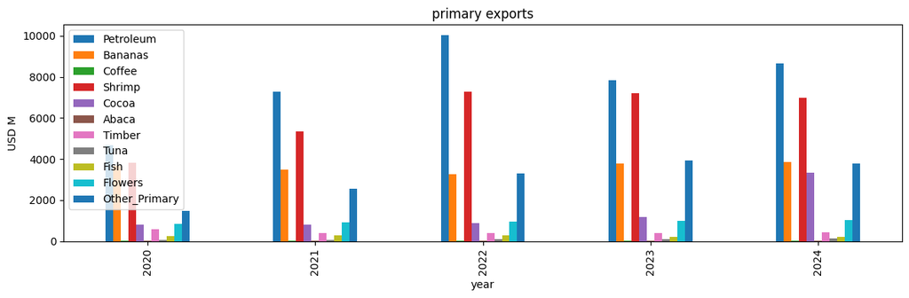

```
Context: Audience=Ministry | Message=Cocoa quadrupled | CTA=Invest in processing
```

```python
# Print the raw annual table — the "data dump" starting point with no design intent
print(df_annual[['year'] + primary_products].round(0).to_string(index=False))

# Plot an unformatted bar chart — no color logic, no title meaning, no message
df_annual.set_index('year')[primary_products].plot(kind='bar', figsize=(12, 4))
plt.title('primary exports'); plt.ylabel('USD M'); plt.tight_layout(); plt.show()

# State the context that will guide all design decisions in the next five lessons
print("\nContext: Audience=Ministry | Message=Cocoa quadrupled | CTA=Invest in processing")
```

## Lesson 2 — Choose an Appropriate Display

Line chart beats bar chart for tracking change over time.

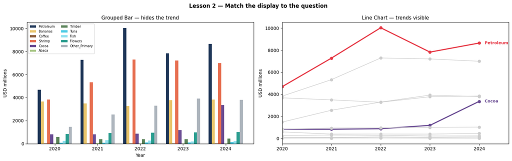

```python
# Define the two color roles used throughout the storytelling section:
# GRAY  = context series (background, not the message)
# HL    = highlighted series that carry the story
GRAY = '#cccccc'
HL   = {'Cocoa': '#6a4c93', 'Petroleum': '#e63946'}

fig, (ax1, ax2) = plt.subplots(1, 2, figsize=(16, 5))

# ── LEFT: wrong choice — grouped bar chart ─────────────────────────────────
# Bar charts show within-year comparisons well but hide the year-over-year trend
df_annual.set_index('year')[primary_products].plot(
    kind='bar', ax=ax1, color=[primary_colors[c] for c in primary_products], width=0.8)
ax1.set_title('Grouped Bar — hides the trend', fontsize=11)
ax1.set_xlabel('Year'); ax1.set_ylabel('USD millions')
ax1.legend(fontsize=7, ncol=2); ax1.tick_params(axis='x', rotation=0)

# ── RIGHT: right choice — line chart ──────────────────────────────────────
# Line charts make direction and rate of change immediately readable
for cat in primary_products:
    col = HL.get(cat, GRAY); lw = 2.5 if cat in HL else 1.1
    ax2.plot(df_annual['year'], df_annual[cat], marker='o', color=col, linewidth=lw)
    if cat in HL:  # only label the highlighted series to reduce clutter
        ax2.text(df_annual['year'].iloc[-1]+0.05, df_annual[cat].iloc[-1],
                 '  '+cat, color=col, fontsize=9, va='center', fontweight='bold')
ax2.set_title('Line Chart — trends visible', fontsize=11)
ax2.set_xticks(df_annual['year']); ax2.set_ylabel('USD millions')
ax2.set_xlim(df_annual['year'].min(), df_annual['year'].max()+0.6)  # extra space for labels
plt.suptitle('Lesson 2 — Match the display to the question', fontsize=12, fontweight='bold')
plt.tight_layout(); plt.show()
```

## Lesson 3 — Eliminate Clutter

Direct labels, no legend, no spines.

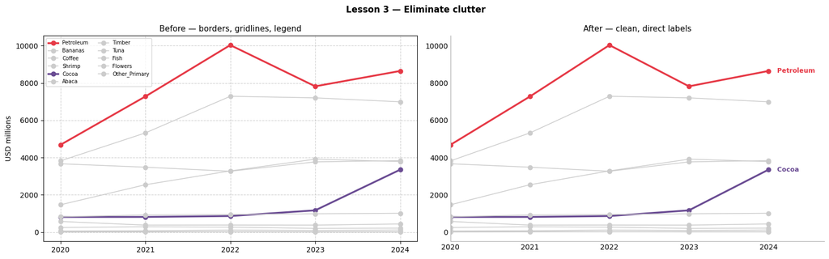

```python
fig, (ax1, ax2) = plt.subplots(1, 2, figsize=(16, 5))

# ── LEFT: before — cluttered version ──────────────────────────────────────
for cat in primary_products:
    col = HL.get(cat, GRAY); lw = 2.5 if cat in HL else 1.1
    ax1.plot(df_annual['year'], df_annual[cat], marker='o', color=col, linewidth=lw, label=cat)
ax1.set_title('Before — borders, gridlines, legend', fontsize=11)
ax1.grid(True, linestyle='--', alpha=0.6)  # heavy grid adds visual noise
ax1.legend(fontsize=7, ncol=2)             # legend forces eye to jump back and forth
ax1.set_xticks(df_annual['year']); ax1.set_ylabel('USD millions')

# ── RIGHT: after — decluttered version ────────────────────────────────────
for cat in primary_products:
    col = HL.get(cat, GRAY); lw = 2.5 if cat in HL else 1.1
    ax2.plot(df_annual['year'], df_annual[cat], marker='o', color=col, linewidth=lw)
    if cat in HL:
        # Direct label at the end of each highlighted line — replaces the legend
        ax2.text(df_annual['year'].iloc[-1]+0.05, df_annual[cat].iloc[-1],
                 '  '+cat, color=col, fontsize=9, va='center', fontweight='bold')

# Remove top and right spines — they frame the data but add no information
for spine in ['top','right']:
    ax2.spines[spine].set_visible(False)
# Soften the remaining spines so they recede visually
ax2.spines['left'].set_color('#aaa'); ax2.spines['bottom'].set_color('#aaa')
ax2.tick_params(length=0)  # remove tick marks — the grid already shows scale
ax2.set_title('After — clean, direct labels', fontsize=11)
ax2.set_xticks(df_annual['year'])
ax2.set_xlim(df_annual['year'].min(), df_annual['year'].max()+0.7)
plt.suptitle('Lesson 3 — Eliminate clutter', fontsize=12, fontweight='bold')
plt.tight_layout(); plt.show()
```

## Lesson 4 — Draw Attention Where You Want It

All context series → gray. Message series → color.

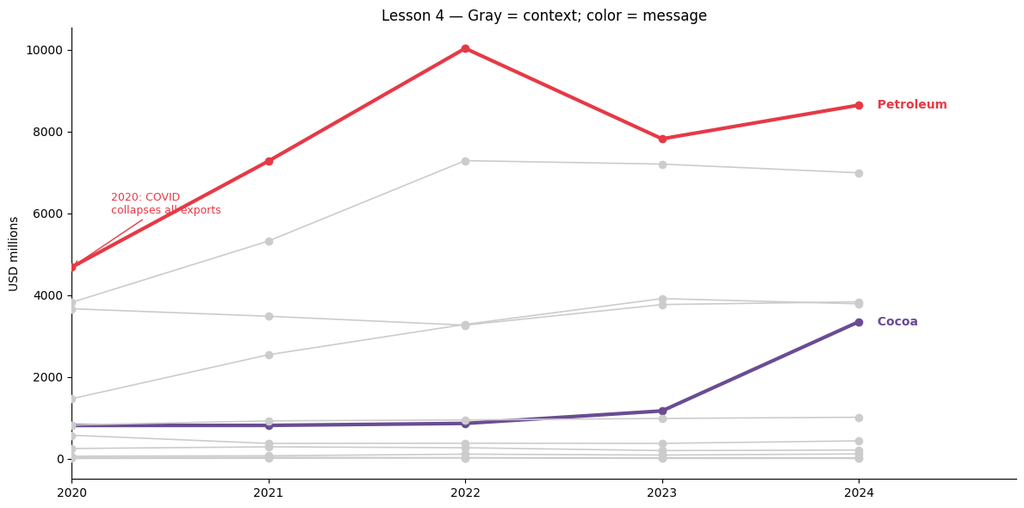

```python
fig, ax = plt.subplots(figsize=(12, 6))

# Color rule: highlighted products get their full color; all others get gray.
# Gray = context (background information); color = message (what the story is about).
for cat in primary_products:
    col = HL.get(cat, GRAY); lw = 3.0 if cat in HL else 1.2
    ax.plot(df_annual['year'], df_annual[cat], marker='o', color=col, linewidth=lw, zorder=3)
    if cat in HL:
        ax.text(df_annual['year'].iloc[-1]+0.05, df_annual[cat].iloc[-1],
                '  '+cat, color=col, fontsize=10, va='center', fontweight='bold')

# Annotation: point the reader's attention to the key event (COVID 2020 shock)
# xy = the exact data point the arrow tip lands on
# xytext = where the annotation text is placed
ax.annotate('2020: COVID\ncollapses all exports',
            xy=(2020, float(df_annual[df_annual['year']==2020]['Petroleum'])),
            xytext=(2020.2, 6000), fontsize=9, color='#e63946',
            arrowprops=dict(arrowstyle='->', color='#e63946'))

# Remove distracting spines
for spine in ['top','right']:
    ax.spines[spine].set_visible(False)
ax.set_title('Lesson 4 — Gray = context; color = message', fontsize=12)
ax.set_xticks(df_annual['year'])
ax.set_xlim(df_annual['year'].min(), df_annual['year'].max()+0.8)
ax.set_ylabel('USD millions'); plt.tight_layout(); plt.show()
```